# Coursera Reproducible Research Project 1

Raghunath 9/2/2017

This assignment makes use of data from a personal activity monitoring device. This device collects data at 5 minute intervals through out the day. The data consists of two months of data from an anonymous individual collected during the months of October and November, 2012 and include the number of steps taken in 5 minute intervals each day.

Load and preprocessing the data:

```r
library(ggplot2)
setwd("C:/Stuff/Work/Coursera/RR/Course Project 1")

if(!file.exists("./data"))
{dir.create("./data")}

fileUrl <- "https://d396qusza40orc.cloudfront.net/repdata%2Fdata%2Factivity.zip"
download.file(fileUrl,destfile="./data/Dataset.zip")

unzip(zipfile="./data/Dataset.zip",exdir="./data")

activity <- read.csv("C:/Stuff/Work/Coursera/RR/Course Project 1/data/activity.csv", stringsAsFactors=FALSE)

activity$date <- as.Date(activity$date, "%Y-%m-%d")
names(activity)<-c("No_of_Steps","Date","Interval_Id")
```

#### Calculate number of steps taken per day

1. Calculating total number of steps taken per day and plotting a histogram.

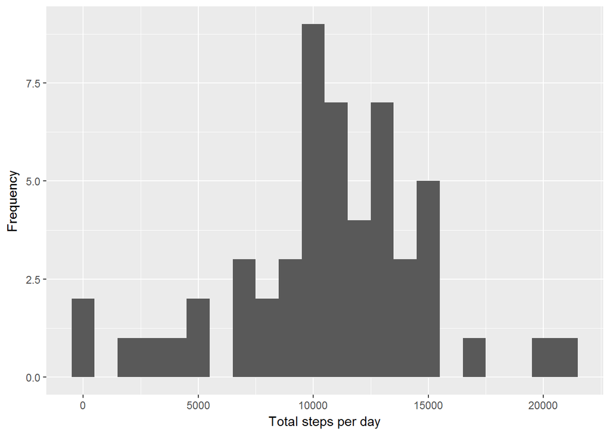

```r
steps_per_day<-aggregate(No_of_Steps~Date,activity,sum)

qplot(steps_per_day$No_of_Steps, xlab='Total steps per day', ylab='Frequency', binwidth=1000)
```

```r
mean_steps<-mean(steps_per_day$No_of_Steps)
mean_steps
```

```
## [1] 10766.19
```

```r
median_steps<-median(steps_per_day$No_of_Steps)
median_steps
```

```
## [1] 10765
```

#### What is the average daily activity pattern?

1. We will first create a time series plot of the 5-minute interval and the average number of steps taken, averaged across all days

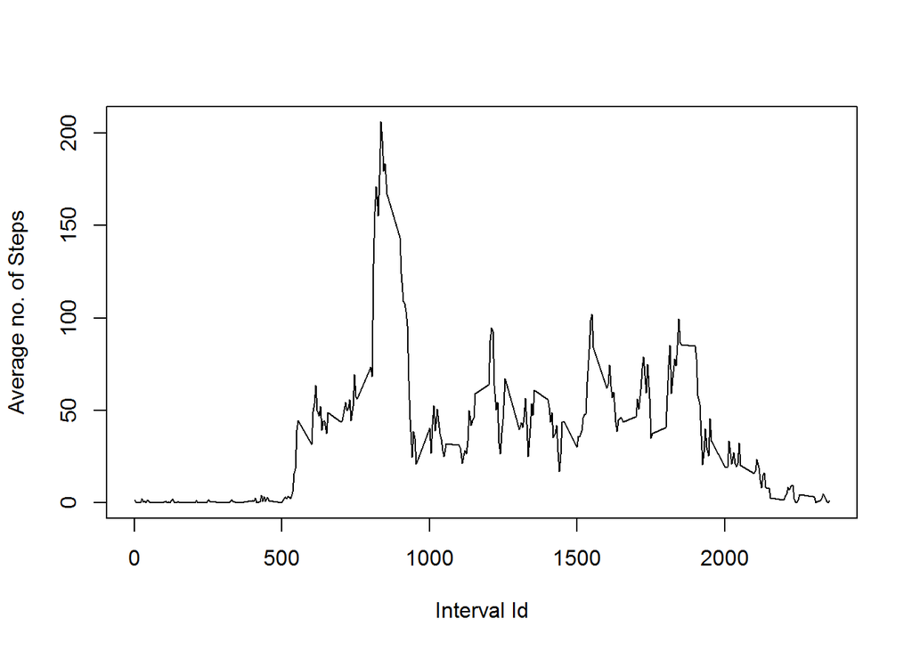

```r
average_daily<-aggregate(No_of_Steps~Interval_Id,activity,mean,na.rm=TRUE)

plot(average_daily$Interval_Id,average_daily$No_of_Steps,type="l",xlab="Interval Id",ylab="Average no. of Steps")
```

```r
Most_Active_IntervalId<-average_daily[which.max(average_daily$No_of_Steps),2]
```

#### Imputing Missisng values

```r
Number_NA<-sum(as.numeric(is.na(activity$No_of_Steps)))

Indices_NA<-which(is.na(activity$No_of_Steps))

Imputed_activity<-activity
Imputed_activity[Indices_NA,1]<-average_daily[which(average_daily[,1] %in% activity[Indices_NA,3]),2]
```

1. The number of missing values is 2304.
2. Imputation of missing values is done considering the mean for the particular 5-minute interval in which number of steps taken is unknown.
3. We will plot a histogram of the total number of steps taken each day after imputing the missing values. And recalculate the mean and median.

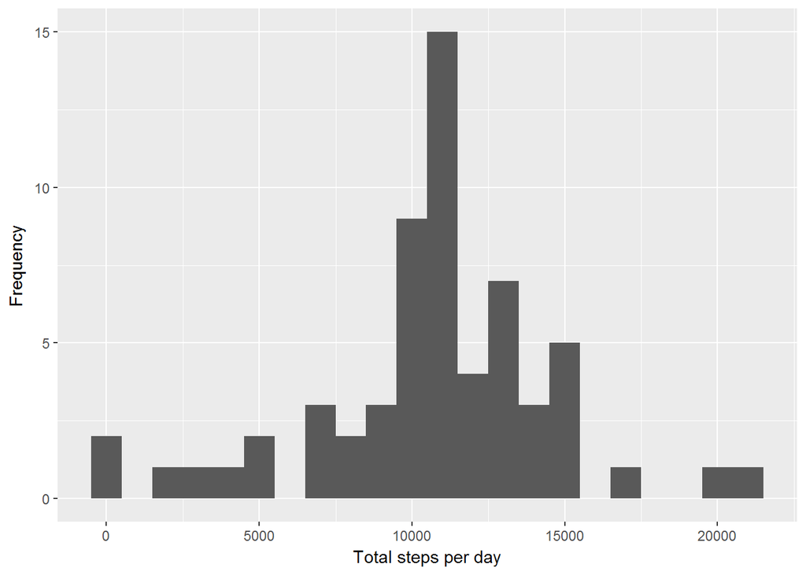

```r
Imputed_steps_per_day<-aggregate(No_of_Steps~Date,Imputed_activity,sum)
qplot(Imputed_steps_per_day$No_of_Steps, xlab='Total steps per day', ylab='Frequency', binwidth=1000)
```

```r
Imputed_mean_steps<-mean(Imputed_steps_per_day$No_of_Steps)
Imputed_median_steps<-median(Imputed_steps_per_day$No_of_Steps)
```

### Are there differences in activity patterns between weekdays and weekends?

1. Creating a new factor variable in the dataset with two levels - “weekday” and “weekend” indicating whether a given date is a weekday or weekend day.

```r
Imputed_activity$WeekDay<-weekdays(Imputed_activity$Date)

Imputed_activity$WeekDay<-(as.numeric(Imputed_activity$WeekDay %in% c("Saturday","Sunday")))

WorkingDay_Rows<-which(Imputed_activity$WeekDay==0)
Imputed_activity[WorkingDay_Rows,4]<-"WorkingDays"
WorkingDay_Rows<-which(Imputed_activity$WeekDay==1)
Imputed_activity[WorkingDay_Rows,4]<-"Weekends"

Imputed_activity$WeekDay<-as.factor(Imputed_activity$WeekDay)
```

2. A panel plot containing a time series plot of the 5-minute intervaland the average number of steps taken, averaged across all weekday days or weekend days .

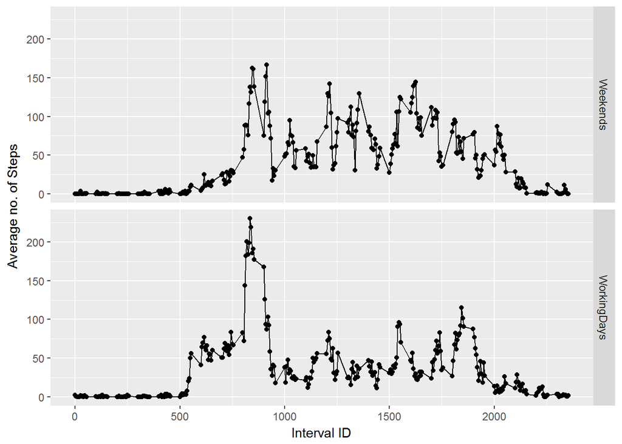

```r
Imputed_average_daily<-aggregate(No_of_Steps~Interval_Id+WeekDay,Imputed_activity,mean,na.rm=TRUE)

g<-ggplot(Imputed_average_daily,aes(Interval_Id,No_of_Steps))
g1<-g+geom_point()+facet_grid(WeekDay ~ .)+geom_line()+xlab("Interval ID")+ylab("Average no. of Steps")

print(g1)
```

Using Base Plotting System :

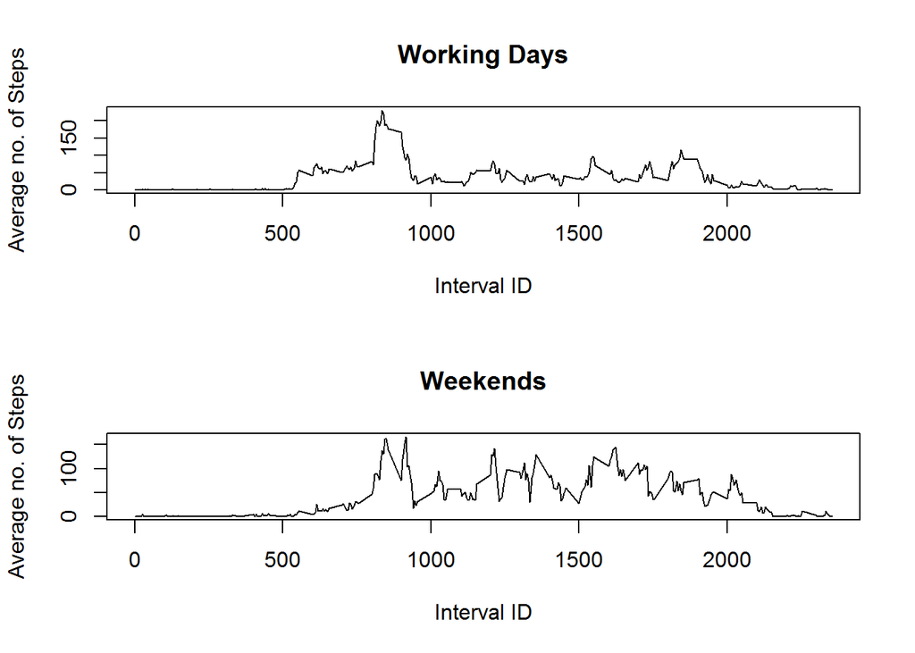

```r
par(mfrow=c(2,1))
Imputed_activity_WorkingDays<-Imputed_activity[which(Imputed_activity$WeekDay=="WorkingDays"),]
average_daily_WorkingDays<-aggregate(No_of_Steps~Interval_Id,Imputed_activity_WorkingDays,mean,na.rm=TRUE)
plot(average_daily_WorkingDays$Interval_Id,average_daily_WorkingDays$No_of_Steps,type="l",xlab="Interval ID",ylab="Average no. of Steps",main="Working Days")

Imputed_activity_Weekends<-Imputed_activity[which(Imputed_activity$WeekDay=="Weekends"),]
average_daily_weekends<-aggregate(No_of_Steps~Interval_Id,Imputed_activity_Weekends,mean,na.rm=TRUE)
plot(average_daily_weekends$Interval_Id,average_daily_weekends$No_of_Steps,type="l",xlab="Interval ID",ylab="Average no. of Steps",main="Weekends")
```